# Reproducible Research: Peer Assessment 1

by Mario Gamboa

## Loading and preprocessing the data

Data is loaded directly from the source specified on the assignment, this assures the raw information is used as part of the analysis. Nevertheless, once downloaded and for performance reasons, a check is performed and if the data exists locally, it is used from the local store.

```r
rawURL = "https://d396qusza40orc.cloudfront.net/repdata%2Fdata%2Factivity.zip"

if (!file.exists("activity.zip")) {
      download.file(url = rawURL, destfile = "activity.zip", method = "curl")
}

### Check for existing datafile, unzip if needed
if(!file.exists("data")) { dir.create("data") }

if (!file.exists("data/activity.csv")){
      unzip(zipfile = "activity.zip", exdir = "data", overwrite = TRUE)
}
```

```r
activityDS        <- read.csv("data/activity.csv")
activityDS$date   <- as.Date(activityDS$date)
activityDS$dateTime   <- as.POSIXct(paste(activityDS$date, "GMT"), tz="GMT")
activityDS$dateTime <- activityDS$dateTime + as.difftime(activityDS$interval, units="mins")
```

## What is mean total number of steps taken per day?

The number of steps taken per day is calculaed with an aggregate function

```r
library(stats)
dailySteps <- aggregate( steps~date, activityDS, FUN=sum, na.rm=TRUE )
```

A historam plot of the information shows steps taken per day

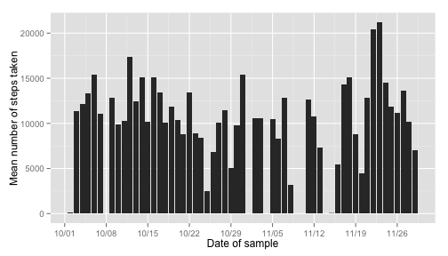

```r
library(scales)
library(ggplot2)

qplot(date, steps, data=dailySteps, geom="blank") +
      geom_bar(stat = "identity") +
      xlab("Date of sample")+
      ylab("Mean number of steps taken")+
      scale_x_date(labels = date_format("%m/%d"),
            breaks = date_breaks("week"))
```

The mean and median of steps taken per day is calculated using *data.table* functions for simplicity. It is interesting to see how the median for each of the dates is zero, this is caused by the large number of observations with zero value on the dataset.

```r
library(data.table)

dt <- data.table(activityDS)
dt[!is.na(steps),
   list(count=length(steps),
      sum=sum(steps),
      mean=mean(steps),
      median=median(steps)),
   by=date]
```

```
##           date count   sum    mean median
##  1: 2012-10-02   288   126  0.4375      0
##  2: 2012-10-03   288 11352 39.4167      0
##  3: 2012-10-04   288 12116 42.0694      0
##  4: 2012-10-05   288 13294 46.1597      0
##  5: 2012-10-06   288 15420 53.5417      0
##  6: 2012-10-07   288 11015 38.2465      0
##  7: 2012-10-09   288 12811 44.4826      0
##  8: 2012-10-10   288  9900 34.3750      0
##  9: 2012-10-11   288 10304 35.7778      0
## 10: 2012-10-12   288 17382 60.3542      0
## 11: 2012-10-13   288 12426 43.1458      0
## 12: 2012-10-14   288 15098 52.4236      0
## 13: 2012-10-15   288 10139 35.2049      0
## 14: 2012-10-16   288 15084 52.3750      0
```

[output cut: 40 more lines]

## What is the average daily activity pattern?

Calculate the average number of steps taken per interval on the data series. This information to properly plot the information.

```r
intervalSteps <- aggregate( steps~interval, activityDS, FUN=mean, na.rm=TRUE )
```

Create the plot with the information to identify which part of the day registers the maximum number of steps.

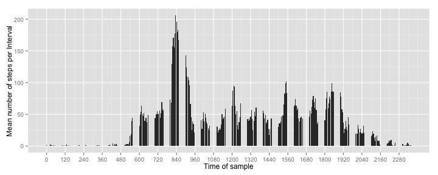

```r
qplot(interval, steps, data=intervalSteps, geom="blank") +
      geom_bar(stat = "identity") +
      xlab("Time of sample")+
      ylab("Mean number of steps per Interval")+
      scale_x_continuous(breaks = seq(from=0, to=2355, by=120))
```

```r
maxStepsInterval <- intervalSteps[which.max(intervalSteps$steps), ]
timeInterval <- strftime(
      as.POSIXct("2000-01-01 0:0:0") +as.difftime(maxStepsInterval[1,1],units="mins"),
      format="%I:%M:%S %p")
```

## Imputing missing values

- Calculate and report the total number of missing values in the dataset (i.e. the total number of rows with NAs):

```r
countNA <- sum(is.na(activityDS))
```

there are **2304** missing values on the dataset.

- Repair the dataset by filling in the NA values with the average information for the corresponding 5 minute interval on the whole dataset. That is used to avoid skewing of informtation by having NA values. Then a new dataset is created with the updated information.

```r
newADS <- merge(activityDS, intervalSteps, by="interval")
newADS$steps.x[is.na(newADS$steps.x)] <- newADS[is.na(newADS$steps.x),5]
newADS <- newADS[c(2,3,1,4)]
names(newADS) <- c("steps","date","interval","dateTime")
```

Make a histogram of the total number of steps taken each day and Calculate and report the mean and median total number of steps taken per day. Do these values differ from the estimates from the first part of the assignment? What is the impact of imputing missing data on the estimates of the total daily number of steps?

The results show a very similar histogram, but the median per day has changed.

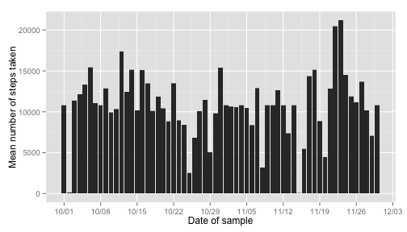

```r
dailySteps <- aggregate( steps~date, newADS, FUN=sum, na.rm=TRUE )

qplot(date, steps, data=newADS, geom="blank") +
      geom_bar(stat = "identity") +
      xlab("Date of sample")+
      ylab("Mean number of steps taken")+
      scale_x_date(labels = date_format("%m/%d"),
            breaks = date_breaks("week"))
```

Some days now present medians other than zero as it was on the original dataset.

```r
dt <- data.table(newADS[order(newADS$date),])
dt[!is.na(steps),
   list(count=length(steps),
      sum=sum(steps),
      mean=mean(steps),
      median=median(steps)),
   by=date]
```

```
##           date count   sum    mean median
##  1: 2012-10-01   288 10766 37.3826  34.11
##  2: 2012-10-02   288   126  0.4375   0.00
##  3: 2012-10-03   288 11352 39.4167   0.00
##  4: 2012-10-04   288 12116 42.0694   0.00
##  5: 2012-10-05   288 13294 46.1597   0.00
##  6: 2012-10-06   288 15420 53.5417   0.00
##  7: 2012-10-07   288 11015 38.2465   0.00
##  8: 2012-10-08   288 10766 37.3826  34.11
##  9: 2012-10-09   288 12811 44.4826   0.00
## 10: 2012-10-10   288  9900 34.3750   0.00
## 11: 2012-10-11   288 10304 35.7778   0.00
## 12: 2012-10-12   288 17382 60.3542   0.00
## 13: 2012-10-13   288 12426 43.1458   0.00
## 14: 2012-10-14   288 15098 52.4236   0.00
```

[output cut: 48 more lines]

## Are there differences in activity patterns between weekdays and weekends?

*Create a new factor variable in the dataset with two levels – “weekday” and “weekend” indicating whether a given date is a weekday or weekend day.* The new dataset now properly marks which observations correspond to weekday vs weekend.

```r
newADS$dayType <- "weekday"
newADS$dayType[weekdays(newADS$date)=="Sunday"] <- "weekend"
newADS$dayType[weekdays(newADS$date)=="Saturday"] <- "weekend"
newADS$dayType <- as.factor(newADS$dayType)
```

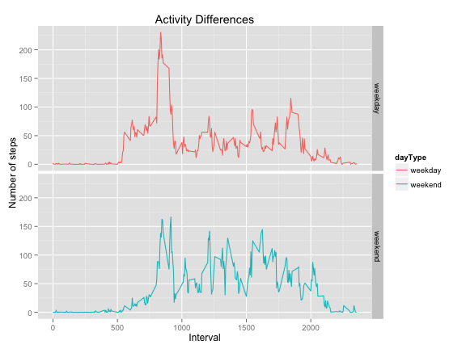

```r
intervalSteps2 <- aggregate( steps~interval+dayType, newADS, FUN=mean, na.rm=TRUE )

ggplot(data = intervalSteps2, aes(y=steps, x=interval, group = dayType, color=dayType)) +
      geom_line() +
      ggtitle("Activity Differences") +
      facet_grid(dayType ~ .) +
      labs(x="Interval",
           y="Number of steps")
```

Further analysis is necessary to determine specific causes for this differences.